# Project: Diagnostic Growth in UEC

SU actions following steering group meeting on 03/09/2024

Published

September 17, 2024

# 1 Background

In Phase I of the project, we seek answers to five questions:

1. How has the average number of tests per ED attendance changed over time?
2. For each of the 20+ test types, how much more likely is it that a patient will receive a test in ED in year 2023/24 than in year 2019/20?
3. What proportion of the growth in each test, can be attributed to: (a) increases in raw demand; (b) changes in case-mix; and (c) changes in the propensity to test (i.e. clinical practice)?
4. How much (net) time does a test add to a patient’s stay in ED?
5. How do tests influence decisions to admit?

To address these questions, we will rely on SUS A&E and EC data sets. Whilst these are relatively high-quality sources, we are aware of substantial variation in recording practices, across the population of provider trusts and over time. If overlooked, this variation is likely to affect the *reliability* and *validity* of our results.

It is therefore our intention to use data sampling (and use different samples to answer the different types of question). We will include a provider in a sample if the quality of their data submissions meet our requirements for the given question.

We expect this approach to improve the reliability and validity of our results. However, since we also wish make general statements about the effect of diagnostic testing on urgent and emergency care, we must ensure that our sample and our population (in each case) have similar properties. Our sample of providers must be *representative* of the population of providers.

There is a trade-off to be made here. The highest quality data, taken from a small number of providers, may increase the reliability of our results. But the smaller the sample of providers, the less likely it is to be representative of the population of providers.

Mindful of this trade-off, we set out our recommendations for the sample of providers to be used in each analysis.

# 2 Recommendations: Q1

1. *How has the average number of tests per ED attendance changed over time?*

This analysis covers a period of 12 years and therefore spans A&E and EC data sets (each of which has a slightly different structure).

We identified 99 providers with provider codes that survived across the 12 year study period and that, in addition, passed basic data quality checks. These 99 providers represent the total population of providers that we might have used for our analysis had data quality been universally high.

Providers were included in our sample if their data submissions met the quality required for this question. Here, the study period is relatively long but we have few variables to examine. We are looking to see that:

1. Throughout the study period, providers have had consistently high levels of recording of the investigation fields.
2. For attendances in which multiple investigations of the same type have been carried out, providers have recorded each instance of the investigation (and have been consistent in this practice over the whole study period).

We established that 28 providers met these criteria. The providers we intend to use for our sample are given in Table 1. In the adjacent tab, Table 2 suggests that this sample of 28 providers is widely representative of the population of providers. We note that the sample includes higher proportions of larger providers and providers in London, and lower proportions of smaller providers and providers in the East of England.

**Sample of Providers (for Q1)**

Table 1: Sample of Providers Recommended for Question 1

| id | Provider_Code | Provider_Name |
| --- | --- | --- |
| 1 | R1F | Isle Of Wight NHS Trust |
| 2 | R1H | Barts Health NHS Trust |
| 3 | RAX | Kingston Hospital NHS Foundation Trust |
| 4 | RBL | Wirral University Teaching Hospital NHS Foundation Trust |
| 5 | RDU | Frimley Health NHS Foundation Trust |
| 6 | REF | Royal Cornwall Hospitals NHS Trust |
| 7 | RF4 | Barking, Havering And Redbridge University Hospitals NHS Trust |
| 8 | RHM | University Hospital Southampton NHS Foundation Trust |
| 9 | RJ1 | Guy's And St Thomas' NHS Foundation Trust |
| 10 | RJ2 | The Lewisham And Greenwich NHS Trust |
| 11 | RKB | University Hospitals Coventry And Warwickshire NHS Trust |
| 12 | RLQ | Wye Valley NHS Trust |
| 13 | RM1 | Norfolk And Norwich University Hospitals NHS Foundation Trust |
| 14 | RNS | Northampton General Hospital NHS Trust |
| 15 | RP5 | Doncaster And Bassetlaw Teaching Hospitals NHS Foundation Trust |
| 16 | RPA | Medway NHS Foundation Trust |
| 17 | RQX | Homerton Healthcare NHS Foundation Trust |
| 18 | RR8 | Leeds Teaching Hospitals NHS Trust |
| 19 | RRK | University Hospitals Birmingham NHS Foundation Trust |
| 20 | RTD | The Newcastle Upon Tyne Hospitals NHS Foundation Trust |
| 21 | RTH | Oxford University Hospitals NHS Foundation Trust |
| 22 | RTX | University Hospitals Of Morecambe Bay NHS Foundation Trust |
| 23 | RWA | Hull University Teaching Hospitals NHS Trust |
| 24 | RWY | Calderdale And Huddersfield NHS Foundation Trust |
| 25 | RX1 | Nottingham University Hospitals NHS Trust |
| 26 | RXF | Mid Yorkshire Hospitals NHS Trust |
| 27 | RXN | Lancashire Teaching Hospitals NHS Foundation Trust |
| 28 | RYR | University Hospitals Sussex NHS Foundation Trust |

**Sample Representation (for Q1)**

Table 2: Is the Sample Representative of the Wider Provider Population?

| variable | population | sample | diff |
| --- | --- | --- | --- |
| n_providers | 99 | 28 |  |
| Provider Size (attendances 23/24): |  |  |  |
| att < 70k | 24.2% | 21.4% | −2.8% |
| att 70-94k | 24.2% | 14.3% | −10.0% |
| att 95-129k | 26.3% | 21.4% | −4.8% |
| att > 130k | 25.3% | 42.9% | 17.6% |
| Case-mix-related: |  |  |  |
| arrive_ambulance | 31.2% | 31.6% | 0.4% |
| admitted | 28.2% | 27.8% | −0.4% |
| Patient demographics: |  |  |  |
| age_under_18 | 22.4% | 21.6% | −0.8% |
| age_75_plus | 17.6% | 16.6% | −1.0% |
| urban | 82.9% | 85.8% | 2.9% |
| deprived_20pc | 26.0% | 29.6% | 3.6% |
| region_east_of_england | 12.1% | 3.8% | −8.3% |
| region_london | 13.9% | 20.4% | 6.5% |
| region_midlands | 21.8% | 19.9% | −1.9% |
| region_north_east_and_yorkshire | 19.8% | 25.8% | 6.0% |
| region_north_west | 10.9% | 8.0% | −2.9% |
| region_south_east | 15.4% | 20.4% | 5.0% |
| region_south_west | 6.1% | 1.7% | −4.4% |

# 3 Provisional results for Q1

Figure 1 shows provisional results for Question 1, based on data from the sample of 28 providers identified above. It appears that, overall, test rates have doubled over the study period, from an average of 2 tests per attendance in 2012/13 to 4 tests per attendance in 2023/24. The rate of increase for admitted patients was uneven and appears to have slowed over the period (now normalising after the pandemic-related spike 2020/2021). For the 7 in 10 patients who are are not admitted after an ED attendance, the increase was fairly consistent to 2020. Again, the rate of increase seems to have slowed following the spike in test rates (seen across the majority of test types) in 2020/21.

Figure 1: Estimated average number of tests per ED attendance, in England, between 2012/13 and 2023/24. Source: SUS A&E and EC datasets.

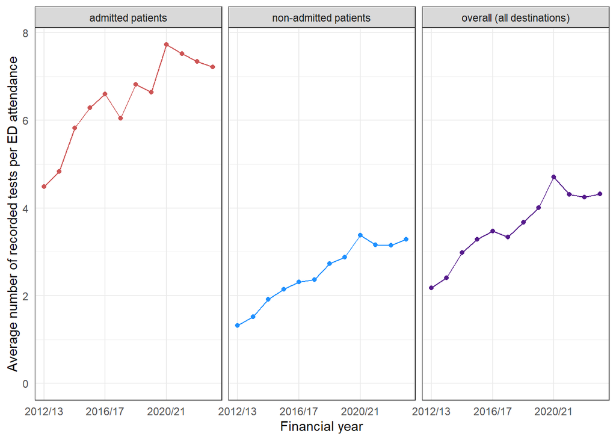

# 4 Recommendations: Qs 2-5

2. *For each of the 20+ test types, how much more likely is it that a patient will receive a test in ED in year 2023/24 than in year 2019/20?*
3. *What proportion of the growth in each test, can be attributed to: (a) increases in raw demand; (b) changes in case-mix; and (c) changes in the propensity to test (i.e. clinical practice)?*
4. *How much (net) time does a test add to a patient’s stay in ED?*
5. *How do tests influence decisions to admit?*

To carry out these analyses, we require only the EC data set, and only two years (provisionally, 2019/20 and 2023/24). We identified 102 providers with provider codes that survived across this study period and that, in addition, passed basic data quality checks. These 102 providers represent the total population of providers that we might have used for our analysis had data quality been universally high.

Providers were included in our sample if they had all three of *Der_EC_Investigation_All, chiefcompgrp,* and *acuity* complete for 90% of records. (Relaxing this requirement to 85% gave us only four more providers and no improvement in representation.) For Question 4, we also required that time-related variables were largely complete.

We established that 16 providers met these criteria. The providers we intend to use for our sample are given in Table 3. In the adjacent tab, Table 4 suggests that this sample of 16 providers is generally representative of the population of providers. We note that the sample includes higher proportions of larger providers and providers in the Midlands. One of the seven regions, the East of England, is not represented.

**Sample of Providers (for Q2-5)**

Table 3: Sample of Providers Recommended for Questions 2-5

| id | Provider_Code | Provider_Name |
| --- | --- | --- |
| 1 | RCB | York And Scarborough Teaching Hospitals NHS Foundation Trust |
| 2 | RCU | Sheffield Childrens NHS Foundation Trust |
| 3 | RHM | University Hospital Southampton NHS Foundation Trust |
| 4 | RJR | Countess Of Chester Hospital NHS Foundation Trust |
| 5 | RK9 | University Hospitals Plymouth NHS Trust |
| 6 | RKB | University Hospitals Coventry And Warwickshire NHS Trust |
| 7 | RNN | North Cumbria Integrated Care NHS Foundation Trust |
| 8 | RRK | University Hospitals Birmingham NHS Foundation Trust |
| 9 | RVW | North Tees And Hartlepool NHS Foundation Trust |
| 10 | RWD | United Lincolnshire Hospitals NHS Trust |
| 11 | RWJ | Stockport NHS Foundation Trust |
| 12 | RWW | Warrington And Halton Teaching Hospitals NHS Foundation Trust |
| 13 | RX1 | Nottingham University Hospitals NHS Trust |
| 14 | RXF | Mid Yorkshire Hospitals NHS Trust |
| 15 | RYJ | Imperial College Healthcare NHS Trust |
| 16 | RYR | University Hospitals Sussex NHS Foundation Trust |

**Sample Representation (for Q2-5)**

Table 4: Is the Sample Representative of the Wider Provider Population?

| variable | population | sample | diff |
| --- | --- | --- | --- |
| n_providers | 102 | 16 |  |
| 2023/24 | 54.4% | 54.8% | 0.4% |
| Provider Size (attendances 23/24): |  |  |  |
| att < 70k | 30.4% | 25.0% | −5.4% |
| att 70-94k | 24.5% | 18.8% | −5.8% |
| att 95-129k | 28.4% | 31.2% | 2.8% |
| att > 130k | 16.7% | 25.0% | 8.3% |
| Case-mix-related: |  |  |  |
| arrive_ambulance | 30.8% | 32.5% | 1.7% |
| admitted | 29.0% | 32.7% | 3.7% |
| Patient demographics: |  |  |  |
| age_under_18 | 23.0% | 22.8% | −0.2% |
| age_75_plus | 18.1% | 18.6% | 0.5% |
| urban | 82.9% | 83.5% | 0.6% |
| deprived_20pc | 26.2% | 29.5% | 3.3% |
| region_east_of_england | 13.3% | 0.0% | −13.3% |
| region_london | 11.0% | 6.5% | −4.5% |
| region_midlands | 21.2% | 34.6% | 13.4% |
| region_north_east_and_yorkshire | 20.6% | 26.2% | 5.6% |
| region_north_west | 12.5% | 12.1% | −0.4% |
| region_south_east | 15.5% | 15.3% | −0.2% |
| region_south_west | 6.0% | 5.3% | −0.7% |